# Fichas de estado e dinâmica — protótipo

Áreas Prioritárias do Cerrado e Pantanal · 2ª atualização · Ficha de estado e dinâmica 2012–2025

## Nascente Uruçui código 29

**UF**

PI

**Área**

70.177 ha

**Bioma (IBGE 2019)**

Cerrado 100%

**Importância biológica**

Extremamente Alta

**Prioridade de ação**

Extremamente Alta

**Ações**

Criação de UC de uso sustentável

Estado em 2025 56% 50–80% de vegetação natural · 39.229 ha

Dinâmica 2012–2025 Perda muito intensa −3,23 ± 0,52%/ano · tendência abaixo de −2%/ano

Principal vetor de conversão soja 54% da vegetação convertida entre 2012 e 2025

- **Aceleração** — a perda em 2018–2025 foi maior que em 2012–2018 em mais de 0,5 p.p./ano, acima do ruído

### Mapa de mudanças 2012–2025

Comparação dos grupos de nível 1 do MapBiomas em 2012 e 2025. A área está em cores plenas e contornada; o entorno aparece esmaecido, como contexto. O mapa é ilustrativo, em coordenadas geográficas, com escala aproximada; as áreas da legenda vêm das tabelas.

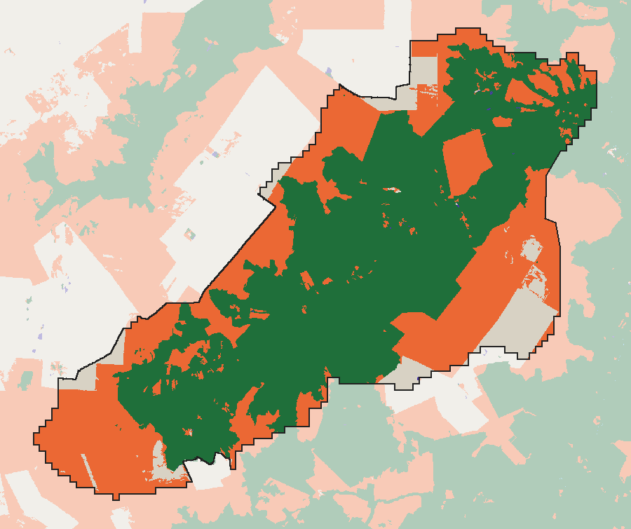

10 km

- Vegetação natural estável39.203 ha · 55,9%
- Perda de vegetação natural26.040 ha · 37,1%
- Ganho de vegetação natural26 ha · 0,0%
- Uso antrópico estável4.910 ha · 7,0%

### Trajetória da área não convertida

Vegetação natural mais água e areia, índice 2012 = 100: é a base da categoria. A linha tracejada é a matriz fora das áreas prioritárias no bioma Cerrado, como **contexto**; não é uma avaliação de efeito.

[figure not shown]

|  | 2012–2025 | 2012–2018 | 2018–2025 | Matriz do bioma 2012–2025 |
| --- | --- | --- | --- | --- |
| Tendência líquida (%/ano da vegetação de 2012) | −3,23 | −1,45 | −4,67 | −0,77 |
| Conversão bruta (%/ano) | 3,14 |  |  | 1,33 |
| Regeneração bruta (%/ano) | 0,08 |  |  | 0,45 |

### Composição da paisagem (ha)

|  | 2012 | 2025 | Variação |
| --- | --- | --- | --- |
| Vegetação natural | 65.243 | 39.229 | −26.014 |
| Formação florestal | 2.724 | 2.692 | −32 |
| Formação savânica | 61.754 | 35.775 | −25.979 |
| Formação campestre | 123 | 54 | −69 |
| Campo alagado | 19 | 85 | +66 |
| Outras formações naturais | 623 | 623 | +1 |
| Uso antrópico | 4.936 | 30.950 | +26.014 |
| Pastagem | 36 | 674 | +638 |
| Soja | 1.076 | 18.931 | +17.855 |
| Outras lavouras | 3.704 | 3.932 | +228 |
| Mosaico de usos | 120 | 7.398 | +7.277 |
| Urbano, mineração e outros | 0 | 16 | +16 |

Vegetação natural: 93,0% da área terrestre em 2012 e 55,9% em 2025.

### Para onde foi a vegetação natural de 2012

Vegetação natural em 2012 que era uso antrópico em 2025 (transição direta).

### De onde veio a regeneração

Uso antrópico em 2012 que era vegetação natural em 2025.

### Persistência

| Vegetação natural de 2012 nunca convertida em uso até 2025 | 39.153 ha | 60,0% |
| --- | --- | --- |
| Vegetação natural de 1985 nunca convertida em uso até 2025 | 39.119 ha | 55,8% |
| Parcela da vegetação natural de 2025 nunca convertida desde 1985 |  | 99,7% |

A diferença entre a vegetação de 2025 e a vegetação nunca convertida é vegetação secundária ou regenerada, que conta como natural no MapBiomas.

### Fogo na vegetação natural estável, 1985–2025

Vegetação que permaneceu natural em todos os anos de 1985 a 2025: savana e campo estáveis somam 36.281 ha e floresta estável 2.199 ha. Savana e campo: **acima do esperado** = fogo repetido com intervalos menores que 3 anos (ao menos dois); **abaixo do esperado** = nenhum fogo nos últimos 20 anos (2006–2025), incluindo o que nunca queimou; **de acordo** = os demais casos, que não são uma afirmação de adequação. Floresta: qualquer fogo é afetação. Os dados são apresentados sem juízo de mérito ou de causa.

Acima do esperado · floresta afetadaDe acordo · floresta não afetadaAbaixo do esperado· barras esmaecidas: matriz

[figure not shown]

Matriz = vegetação estável do Cerrado e do Pantanal fora das áreas prioritárias, como contexto. Áreas úmidas (campo e savana alagáveis): mesma regra, só reportada, sem leitura de categoria, porque o regime depende da inundação.

- **Acima do esperado em 63%** da savana e do campo estáveis — depende do limiar: contando só fogo anual, 9%.
- **Floresta afetada por fogo em 65%** da floresta estável — robusto: mantém-se acima de 50% só com pixels de classe estável.

#### Mudança entre 2012–2018 e 2019–2025 (savana e campo estáveis)

|  | 2012–2018 | 2019–2025 | Matriz entre 12°S e 8°S 2012–2018 · 2019–2025 |
| --- | --- | --- | --- |
| Área queimada por ano (% da área estável) | 22,6% | 28,2% |  |
| Área com fogo em anos consecutivos (% da área estável) | 3,4% | 6,4% |  |
| **Fogo em julho–agosto** (% do queimado) | **20%** | **11%** | 27% · 23% |
| Fogo na janela crítica, agosto–outubro (% do queimado; descritor) | 84% | 91% | 76% · 74% |

2012–20182019–2025

[figure not shown]

Julho e agosto são meses sem raios no Cerrado: o fogo nesses meses é iniciado por pessoas. A janela crítica marca o período de maior estresse hídrico da faixa de latitude e é mostrada só como descritor, porque o sentido da sua mudança depende de onde cai o limite da janela. Método: decisão D15 do projeto.

### Alvos de conservação da área (2ª atualização, listas de 2011–2012)

| Grupo | Alvos |
| --- | --- |
| Plantas | 23 |
| Mamíferos | 15 |
| Répteis | 8 |
| Aves | 4 |
| Anfíbios | 3 |
| Sistemas de terras | 3 |

**Lista de alvos**

- **Anfíbios:** Dendropsophus cruzi, Rhinella ocellata, Scinax constrictus
- **Aves:** Alipiopsitta xanthops, Anodorhychus hyacinthinus, Conothraupis mesoleuca, Suiriri islerorum
- **Mamíferos:** Carterodon sulcidens, Chrysocyon brachyurus, Cuniculus paca, Leopardus wiedii, Monodelphis kunsi, Myrmechophaga tridactyla, Ozotoceros bezoarticus, Panthera onca, Priodontes maximus, Pteronura brasiliensis, Puma concolor, Tapirus terrestris, Tayassu pecari, Thalpomys cerradensis, Thyroptera devivoi
- **Plantas:** Callisthene fasciculata mart., Callisthene major mart. & zucc., Chrysolaena obovata (less.) dematt., Eugenia dysenterica dc., Guadua paniculata munro, Handroanthus impetiginosus mattos, Handroanthus ochraceus (cham.) mattos, Jacaranda brasiliana (lam.) pers., Lafoensia densiflora pohl, Myrsine guianensis (aubl.) kuntze, Piptocarpha rotundifolia (less.) baker, Psidium myrsinites dc., Qualea grandiflora mart., Qualea jundiahy warm., Qualea multiflora mart., Qualea parviflora mart., Salvertia convallariodora a.st.-hil., Tabebuia aurea (silva manso) benth. & hook.f. ex *, Vernonanthura ferruginea (less.) h.rob., Vochysia cinnamomea pohl, Vochysia gardneri warm., Vochysia haenkeana mart., Zeyheria digitalis (vell.) hoehne & kuhlm.
- **Répteis:** Apostolepis flavotorquata, Bothrops lutzi, Bothrops marmoratus, Chironius flavolineatus, Coleodactylus brachystoma, Hoplocercus spinosus, Phalotris nasutus, Xenodon nattereri
- **Sistemas de terras:** 1bc8n, 1da1n, 1fc3n

As listas são históricas e não representam a lista vigente de espécies ameaçadas.

Áreas Prioritárias do Cerrado e Pantanal · 2ª atualização · Ficha de estado e dinâmica 2012–2025

## Rio Miranda código 252

**UF**

MS

**Área**

**Bioma (IBGE 2019)**

Pantanal 83%; Cerrado 16%

**Importância biológica**

Muito Alta

**Prioridade de ação**

Muito Alta

**Ações**

Corredor / mosaico

Estado em 2025 92% ≥ 80% de vegetação natural · 445.274 ha

Dinâmica 2012–2025 Estável −0,14 ± 0,04%/ano · tendência entre −0,2 e +0,2%/ano e conversão bruta ≤ 0,5%/ano

Principal vetor de conversão pastagem 62% da vegetação convertida entre 2012 e 2025

- **Dinâmica hidrológica** — trocas entre vegetação natural e água/areia são > 20% das trocas brutas; não contam como perda

### Mapa de mudanças 2012–2025

Comparação dos grupos de nível 1 do MapBiomas em 2012 e 2025. A área está em cores plenas e contornada; o entorno aparece esmaecido, como contexto. O mapa é ilustrativo, em coordenadas geográficas, com escala aproximada; as áreas da legenda vêm das tabelas.

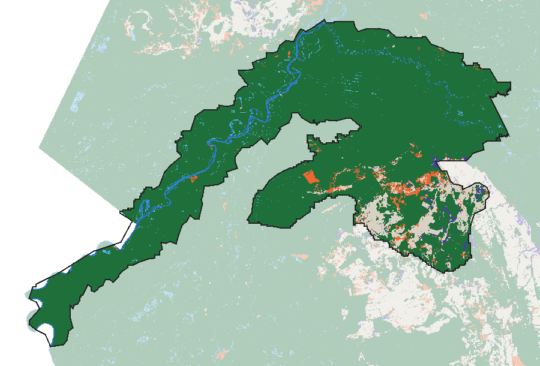

20 km

- Vegetação natural estável437.095 ha · 88,8%
- Perda de vegetação natural10.800 ha · 2,2%
- Ganho de vegetação natural3.328 ha · 0,7%
- Uso antrópico estável27.221 ha · 5,5%
- Água ou areia estável8.150 ha · 1,7%
- Trocas com água ou areia5.506 ha · 1,1%

### Trajetória da área não convertida

Vegetação natural mais água e areia, índice 2012 = 100: é a base da categoria. A linha tracejada é a matriz fora das áreas prioritárias no bioma Pantanal, como **contexto**; não é uma avaliação de efeito. A linha pontilhada mostra só a vegetação natural da área: a oscilação vem das cheias, que não contam como perda.

[figure not shown]

|  | 2012–2025 | 2012–2018 | 2018–2025 | Matriz do bioma 2012–2025 |
| --- | --- | --- | --- | --- |
| Tendência líquida (%/ano da vegetação de 2012) | −0,14 | −0,25 | −0,05 | −0,36 |
| Conversão bruta (%/ano) | 0,24 |  |  | 0,46 |
| Regeneração bruta (%/ano) | 0,11 |  |  | 0,13 |

### Composição da paisagem (ha)

|  | 2012 | 2025 | Variação |
| --- | --- | --- | --- |
| Vegetação natural | 448.523 | 445.274 | −3.249 |
| Formação florestal | 44.422 | 49.052 | +4.630 |
| Formação savânica | 127.347 | 107.574 | −19.773 |
| Savana alagada | 2.443 | 2.866 | +422 |
| Formação campestre | 260.697 | 256.840 | −3.857 |
| Campo alagado | 13.614 | 28.942 | +15.329 |
| Uso antrópico | 30.560 | 38.036 | +7.476 |
| Pastagem | 27.054 | 24.813 | −2.241 |
| Soja | 86 | 6.811 | +6.725 |
| Outras lavouras | 1.165 | 2.630 | +1.465 |
| Mosaico de usos | 2.141 | 3.552 | +1.411 |
| Silvicultura | 87 | 190 | +103 |
| Urbano, mineração e outros | 27 | 40 | +13 |
| Natural não vegetado | 13.016 | 8.789 | −4.227 |
| Água | 13.016 | 8.789 | −4.227 |

Vegetação natural: 93,6% da área terrestre em 2012 e 92,1% em 2025.

### Para onde foi a vegetação natural de 2012

Vegetação natural em 2012 que era uso antrópico em 2025 (transição direta).

### De onde veio a regeneração

Uso antrópico em 2012 que era vegetação natural em 2025.

Dinâmica hidrológica (fora da contabilidade): 628 ha de vegetação natural de 2012 eram água ou areia em 2025, e 4.851 ha fizeram o caminho inverso. Vegetação que virou água e ficou água em 2020–2025 (possível reservatório): 83 ha.

### Persistência

| Vegetação natural de 2012 nunca convertida em uso até 2025 | 435.863 ha | 97,2% |
| --- | --- | --- |
| Vegetação natural de 1985 nunca convertida em uso até 2025 | 307.966 ha | 90,4% |
| Parcela da vegetação natural de 2025 nunca convertida desde 1985 |  | 69,2% |

A diferença entre a vegetação de 2025 e a vegetação nunca convertida é vegetação secundária ou regenerada, que conta como natural no MapBiomas. **Nesta área há dinâmica hidrológica:** parte da diferença é vegetação que estava alagada em 1985 (água), não vegetação secundária; a terceira linha subestima a vegetação antiga.

### Fogo na vegetação natural estável, 1985–2025

Vegetação que permaneceu natural em todos os anos de 1985 a 2025: savana e campo estáveis somam 136.079 ha e floresta estável 44.137 ha. Savana e campo: **acima do esperado** = fogo repetido com intervalos menores que 3 anos (ao menos dois); **abaixo do esperado** = nenhum fogo nos últimos 20 anos (2006–2025), incluindo o que nunca queimou; **de acordo** = os demais casos, que não são uma afirmação de adequação. Floresta: qualquer fogo é afetação. Os dados são apresentados sem juízo de mérito ou de causa.

Acima do esperado · floresta afetadaDe acordo · floresta não afetadaAbaixo do esperado· barras esmaecidas: matriz

[figure not shown]

Matriz = vegetação estável do Cerrado e do Pantanal fora das áreas prioritárias, como contexto. Áreas úmidas (campo e savana alagáveis): mesma regra, só reportada, sem leitura de categoria, porque o regime depende da inundação.

- **Acima do esperado em 26%** da savana e do campo estáveis — depende do limiar: contando só fogo anual, 14%.

#### Mudança entre 2012–2018 e 2019–2025 (savana e campo estáveis)

|  | 2012–2018 | 2019–2025 | Matriz ao sul de 18°S 2012–2018 · 2019–2025 |
| --- | --- | --- | --- |
| Área queimada por ano (% da área estável) | 7,3% | 17,2% |  |
| Área com fogo em anos consecutivos (% da área estável) | 3,4% | 10,6% |  |
| **Fogo em julho–agosto** (% do queimado) | **20%** | **29%** | 22% · 41% |
| Fogo na janela crítica, julho–setembro (% do queimado; descritor) | 60% | 42% | 66% · 71% |

2012–20182019–2025

[figure not shown]

Julho e agosto são meses sem raios no Cerrado: o fogo nesses meses é iniciado por pessoas. A janela crítica marca o período de maior estresse hídrico da faixa de latitude e é mostrada só como descritor, porque o sentido da sua mudança depende de onde cai o limite da janela. Método: decisão D15 do projeto.

### Alvos de conservação da área (2ª atualização, listas de 2011–2012)

| Grupo | Alvos |
| --- | --- |
| Plantas | 39 |
| Mamíferos | 16 |
| Répteis | 14 |
| Aves | 4 |
| Sistemas de terras | 3 |

**Lista de alvos**

- **Aves:** Alipiopsitta xanthops, Anodorhychus hyacinthinus, Polystictus pectoralis, Sporophila cinnamomea
- **Mamíferos:** Blastocerus dichotomus, Chrysocyon brachyurus, Clyomys laticeps, Cuniculus paca, Leontophitecus chrysopygus, Monodelphis kunsi, Myrmechophaga tridactyla, Oecomys cleberi, Ozotoceros bezoarticus, Panthera onca, Priodontes maximus, Pteronura brasiliensis, Puma concolor, Speothos venaticus, Tapirus terrestris, Thylamys velutinus
- **Plantas:** Annona emarginata (schltdl.) h.rainer, Baccharis dracunculifolia dc., Blepharocalyx salicifolius (kunth) o.berg, Bumelia obtusifolia roem. & schult., Callisthene major mart. & zucc., Caperonia palustris (l.) a.st.-hil., Crateva tapia l., Dasyphyllum brasiliense var. latifolium (d.don) c*, Echinodorus paniculatus micheli, Erythroxylum anguifugum mart., Eugenia aurata o.berg, Eugenia punicifolia (hbk) dc., Ficus calyptroceras (miq.) miq., Ficus krukovii standl., Genipa americana l., Handroanthus impetiginosus mattos, Handroanthus ochraceus (cham.) mattos, Jacaranda caroba (vell.) dc., Jacaranda cuspidifolia mart., Jacaranda decurrens cham., Lessingianthus grandiflorus (less.) h.rob., Myrcia tomentosa (aubl.) dc., Myrsine guianensis (aubl.) kuntze, Paspalum virgatum l., Pfaffia glomerata (spreng.) pedersen, Qualea dichotoma (mart.) warm., Qualea grandiflora mart., Qualea multiflora mart., Qualea parviflora mart., Tabebuia aurea (silva manso) benth. & hook.f. ex *, Tabebuia insignis (miq.) sandwith, Tabebuia roseoalba (ridl.) sandwith, Tetrapterys microphylla (a.juss.) nied., Vernonanthura ferruginea (less.) h.rob., Vernonia rubriramea mart. ex dc., Vochysia cinnamomea pohl, Vochysia divergens pohl, Vochysia tucanorum mart., Zeyheria digitalis (vell.) hoehne & kuhlm.
- **Répteis:** Anolis meridionalis, Bothrops mattogrossensis, Clelia bicolor, Coleodactylus brachystoma, Drymoluber brazili, Eunectes notaeus, Hoplocercus spinosus, Mabuya guaporicola, Micrurus tricolor, Philodryas livida, Phimophis guerini, Psomophis genimaculatus, Tropidurus itambere, Xenodon matogrossensis
- **Sistemas de terras:** 3ac3c, 5ap1n, 5ap5n

As listas são históricas e não representam a lista vigente de espécies ameaçadas.

Áreas Prioritárias do Cerrado e Pantanal · 2ª atualização · Ficha de estado e dinâmica 2012–2025

## Curvelo código 244

**UF**

MG

**Área**

47.564 ha

**Bioma (IBGE 2019)**

Cerrado 100%

**Importância biológica**

Muito Alta

**Prioridade de ação**

Alta

**Ações**

Recuperação; Fomento ao uso sustentável

Estado em 2025 33% 20–50% de vegetação natural · 15.533 ha

Principal vetor de conversão pastagem 58% da vegetação convertida entre 2012 e 2025

Nenhum alerta.

### Mapa de mudanças 2012–2025

Comparação dos grupos de nível 1 do MapBiomas em 2012 e 2025. A área está em cores plenas e contornada; o entorno aparece esmaecido, como contexto. O mapa é ilustrativo, em coordenadas geográficas, com escala aproximada; as áreas da legenda vêm das tabelas.

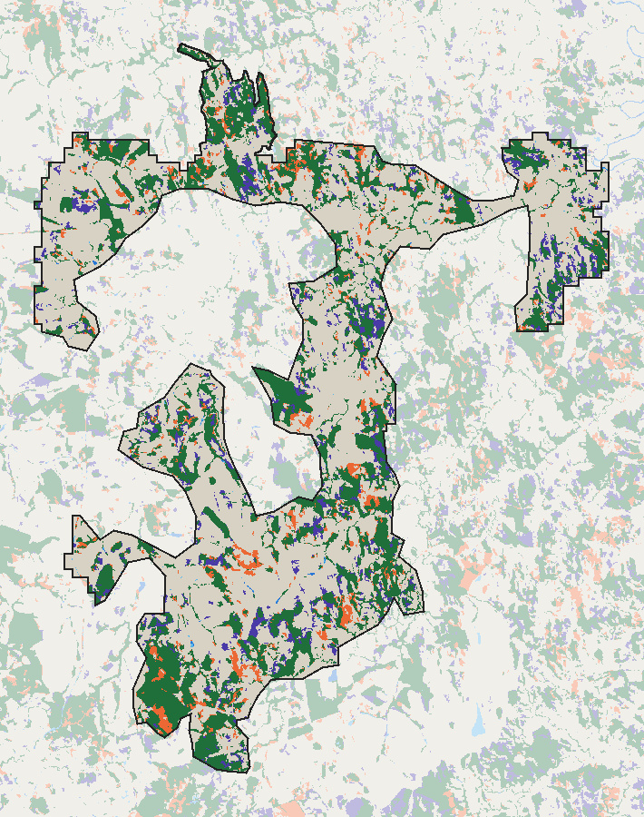

5 km

- Vegetação natural estável12.792 ha · 26,9%
- Perda de vegetação natural2.237 ha · 4,7%
- Ganho de vegetação natural2.739 ha · 5,8%
- Uso antrópico estável29.696 ha · 62,4%
- Água ou areia estável44 ha · 0,1%
- Trocas com água ou areia53 ha · 0,1%

### Trajetória da área não convertida

Vegetação natural mais água e areia, índice 2012 = 100: é a base da categoria. A linha tracejada é a matriz fora das áreas prioritárias no bioma Cerrado, como **contexto**; não é uma avaliação de efeito.

[figure not shown]

[output not shown]

### Composição da paisagem (ha)

|  | 2012 | 2025 | Variação |
| --- | --- | --- | --- |
| Vegetação natural | 15.036 | 15.533 | +497 |
| Formação florestal | 6.753 | 6.837 | +83 |
| Formação savânica | 4.837 | 6.112 | +1.275 |
| Formação campestre | 3.062 | 2.331 | −731 |
| Campo alagado | 383 | 254 | −129 |
| Uso antrópico | 32.472 | 31.942 | −530 |
| Pastagem | 25.885 | 21.815 | −4.069 |
| Soja | 0 | 56 | +56 |
| Outras lavouras | 97 | 366 | +269 |
| Mosaico de usos | 3.173 | 4.386 | +1.213 |
| Silvicultura | 2.794 | 4.675 | +1.882 |
| Urbano, mineração e outros | 524 | 643 | +119 |
| Natural não vegetado | 54 | 87 | +33 |
| Água | 54 | 87 | +33 |

Vegetação natural: 31,6% da área terrestre em 2012 e 32,7% em 2025.

### Para onde foi a vegetação natural de 2012

Vegetação natural em 2012 que era uso antrópico em 2025 (transição direta).

### De onde veio a regeneração

Uso antrópico em 2012 que era vegetação natural em 2025.

Dinâmica hidrológica (fora da contabilidade): 7 ha de vegetação natural de 2012 eram água ou areia em 2025, e 2 ha fizeram o caminho inverso. Vegetação que virou água e ficou água em 2020–2025 (possível reservatório): 2 ha.

### Persistência

| Vegetação natural de 2012 nunca convertida em uso até 2025 | 12.283 ha | 81,7% |
| --- | --- | --- |
| Vegetação natural de 1985 nunca convertida em uso até 2025 | 7.879 ha | 42,6% |
| Parcela da vegetação natural de 2025 nunca convertida desde 1985 |  | 50,7% |

A diferença entre a vegetação de 2025 e a vegetação nunca convertida é vegetação secundária ou regenerada, que conta como natural no MapBiomas.

### Fogo na vegetação natural estável, 1985–2025

Vegetação que permaneceu natural em todos os anos de 1985 a 2025: savana e campo estáveis somam 3.085 ha e floresta estável 4.453 ha. Savana e campo: **acima do esperado** = fogo repetido com intervalos menores que 3 anos (ao menos dois); **abaixo do esperado** = nenhum fogo nos últimos 20 anos (2006–2025), incluindo o que nunca queimou; **de acordo** = os demais casos, que não são uma afirmação de adequação. Floresta: qualquer fogo é afetação. Os dados são apresentados sem juízo de mérito ou de causa.

Acima do esperado · floresta afetadaDe acordo · floresta não afetadaAbaixo do esperado· barras esmaecidas: matriz

[figure not shown]

Matriz = vegetação estável do Cerrado e do Pantanal fora das áreas prioritárias, como contexto. Áreas úmidas (campo e savana alagáveis): mesma regra, só reportada, sem leitura de categoria, porque o regime depende da inundação.

- **Abaixo do esperado em 97%** da savana e do campo estáveis — robusto: mantém-se acima de 50% com limiar de 25 anos (96%).

#### Mudança entre 2012–2018 e 2019–2025 (savana e campo estáveis)

|  | 2012–2018 | 2019–2025 | Matriz ao sul de 18°S 2012–2018 · 2019–2025 |
| --- | --- | --- | --- |
| Área queimada por ano (% da área estável) | 0,1% | 0,1% |  |
| Área com fogo em anos consecutivos (% da área estável) | 0,0% | 0,0% |  |
| **Fogo em julho–agosto** (% do queimado) | **–** | **–** | 22% · 41% |
| Fogo na janela crítica, julho–setembro (% do queimado; descritor) | – | – | 66% · 71% |

“–” nas razões sazonais: fogo insuficiente no subperíodo (menos de 1.000 ha ou de 1% da vegetação aberta estável).

Julho e agosto são meses sem raios no Cerrado: o fogo nesses meses é iniciado por pessoas. A janela crítica marca o período de maior estresse hídrico da faixa de latitude e é mostrada só como descritor, porque o sentido da sua mudança depende de onde cai o limite da janela. Método: decisão D15 do projeto.

### Alvos de conservação da área (2ª atualização, listas de 2011–2012)

| Grupo | Alvos |
| --- | --- |
| Plantas | 58 |
| Répteis | 13 |
| Mamíferos | 11 |
| Aves | 5 |
| Sistemas de terras | 1 |

**Lista de alvos**

- **Aves:** Alectrurus tricolor, Alipiopsitta xanthops, Coryphaspiza melanotis, Poospiza cinerea, Taoniscus nanus
- **Mamíferos:** Carterodon sulcidens, Chrysocyon brachyurus, Clyomys laticeps, Cuniculus paca, Myrmechophaga tridactyla, Ozotoceros bezoarticus, Panthera onca, Priodontes maximus, Puma concolor, Tapirus terrestris, Tayassu pecari
- **Plantas:** Anacardium humile a.st.-hil., Anemopaegma arvense (vell.) stellfeld ex de souza, Aspidosperma camporum mpll.arg., Astraea lobata (l.) klotzsch, Astronium fraxinifolium schott, Astronium graveolens jacq., Callisthene major mart. & zucc., Camarea ericoides a.st.-hil., Campomanesia pubescens (dc.) o.berg, Carpotroche brasiliensis (raddi) endl., Chrysolaena obovata (less.) dematt., Chrysolaena simplex (less.) dematt., Cochlospermum insigne a.st.-hil., Dasyphyllum brasiliense var. latifolium (d.don) c*, Dipteryx alata vogel, Dyckia minarum mez, Eremanthus glomerulatus less., Eugenia aurata o.berg, Eugenia dysenterica dc., Eugenia punicifolia (hbk) dc., Ficus eximia schott, Galactia glaucescens kunth, Gaya domingensis urb., Guadua paniculata munro, Handroanthus impetiginosus mattos, Handroanthus ochraceus (cham.) mattos, Inga fagifolia willd. ex benth, Jacaranda brasiliana (lam.) pers., Jacaranda caroba (vell.) dc., Jacaranda decurrens cham., Lessingianthus bardanoides (less.) h.rob., Lessingianthus virgulatus (mart. ex dc.) h.rob., Mandevilla hirsuta (a.rich.) k.schum., Myracrodruon urundeuva allem.o, Myrcia tomentosa (aubl.) dc., Myrcia uberavensis o.berg, Myrsine guianensis (aubl.) kuntze, Ocotea pulchella (nees & mart.) mez, Pfaffia jubata mart., Pfaffia minarum pedersen, Piptocarpha rotundifolia (less.) baker, Psidium myrsinites dc., Pterandra pyroidea a.juss., Qualea dichotoma (mart.) warm., Qualea grandiflora mart., Qualea jundiahy warm., Qualea multiflora mart., Qualea parviflora mart., Rhynchanthera grandiflora (aubl.) dc., Salvertia convallariodora a.st.-hil., Tabebuia aurea (silva manso) benth. & hook.f. ex *, Tabebuia roseoalba (ridl.) sandwith, Vernonanthura ferruginea (less.) h.rob., Vernonia desertorum mart., Vernonia rubriramea mart. ex dc., Vochysia tucanorum mart., Xylopia aromatica (lam.) mart., Zeyheria digitalis (vell.) hoehne & kuhlm.
- **Répteis:** Apostolepis flavotorquata, Atractus pantostictus, Chironius flavolineatus, Chironius quadricarinatus, Drymoluber brazili, Epicrates crassus, Hoplocercus spinosus, Micrablepharus atticolus, Phalotris nasutus, Phimophis guerini, Tropidurus itambere, Tropidurus montanus, Xenodon nattereri
- **Sistemas de terras:** 1cc1n

As listas são históricas e não representam a lista vigente de espécies ameaçadas.

Áreas Prioritárias do Cerrado e Pantanal · 2ª atualização · Ficha de estado e dinâmica 2012–2025

## Entorno TI Kanela - TI Porquinhos código 15

**UF**

MA

**Área**

53.267 ha

**Bioma (IBGE 2019)**

Cerrado 100%

**Importância biológica**

Muito Alta

**Prioridade de ação**

Alta

**Ações**

CAR – boas práticas; Ordenamento territorial

Estado em 2025 86% ≥ 80% de vegetação natural · 45.754 ha

Dinâmica 2012–2025 Perda intensa −1,02 ± 0,15%/ano · tendência entre −2 e −1%/ano

Principal vetor de conversão mosaico de usos 62% da vegetação convertida entre 2012 e 2025

- **Aceleração** — a perda em 2018–2025 foi maior que em 2012–2018 em mais de 0,5 p.p./ano, acima do ruído
- **Baixa confiança** — a tendência está a menos de um erro-padrão de um limite de categoria

### Mapa de mudanças 2012–2025

Comparação dos grupos de nível 1 do MapBiomas em 2012 e 2025. A área está em cores plenas e contornada; o entorno aparece esmaecido, como contexto. O mapa é ilustrativo, em coordenadas geográficas, com escala aproximada; as áreas da legenda vêm das tabelas.

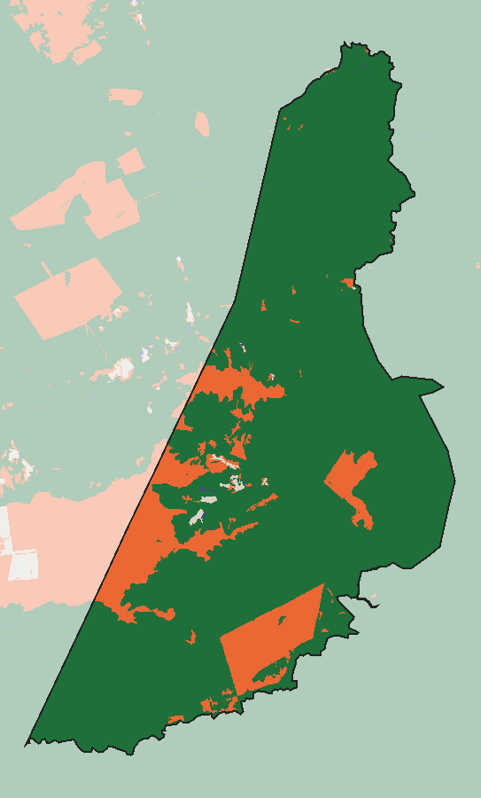

5 km

- Vegetação natural estável45.733 ha · 85,9%
- Perda de vegetação natural7.332 ha · 13,8%
- Ganho de vegetação natural21 ha · 0,0%
- Uso antrópico estável181 ha · 0,3%

### Trajetória da área não convertida

Vegetação natural mais água e areia, índice 2012 = 100: é a base da categoria. A linha tracejada é a matriz fora das áreas prioritárias no bioma Cerrado, como **contexto**; não é uma avaliação de efeito.

[figure not shown]

|  | 2012–2025 | 2012–2018 | 2018–2025 | Matriz do bioma 2012–2025 |
| --- | --- | --- | --- | --- |
| Tendência líquida (%/ano da vegetação de 2012) | −1,02 | −0,81 | −1,50 | −0,77 |
| Conversão bruta (%/ano) | 1,08 |  |  | 1,33 |
| Regeneração bruta (%/ano) | 0,02 |  |  | 0,45 |

### Composição da paisagem (ha)

|  | 2012 | 2025 | Variação |
| --- | --- | --- | --- |
| Vegetação natural | 53.065 | 45.754 | −7.311 |
| Formação florestal | 9.484 | 8.550 | −934 |
| Formação savânica | 32.937 | 29.123 | −3.814 |
| Formação campestre | 10.523 | 7.959 | −2.563 |
| Campo alagado | 121 | 121 | −0 |
| Uso antrópico | 202 | 7.513 | +7.311 |
| Pastagem | 201 | 797 | +596 |
| Soja | 1 | 2.086 | +2.084 |
| Mosaico de usos | 0 | 4.567 | +4.567 |
| Urbano, mineração e outros | 0 | 64 | +64 |
| Natural não vegetado | 0 | 0 | 0 |
| Água | 0 | 0 | 0 |

Vegetação natural: 99,6% da área terrestre em 2012 e 85,9% em 2025.

### Para onde foi a vegetação natural de 2012

Vegetação natural em 2012 que era uso antrópico em 2025 (transição direta).

### De onde veio a regeneração

Uso antrópico em 2012 que era vegetação natural em 2025.

### Persistência

| Vegetação natural de 2012 nunca convertida em uso até 2025 | 45.688 ha | 86,1% |
| --- | --- | --- |
| Vegetação natural de 1985 nunca convertida em uso até 2025 | 45.662 ha | 85,7% |
| Parcela da vegetação natural de 2025 nunca convertida desde 1985 |  | 99,8% |

A diferença entre a vegetação de 2025 e a vegetação nunca convertida é vegetação secundária ou regenerada, que conta como natural no MapBiomas.

### Fogo na vegetação natural estável, 1985–2025

Vegetação que permaneceu natural em todos os anos de 1985 a 2025: savana e campo estáveis somam 37.282 ha e floresta estável 8.263 ha. Savana e campo: **acima do esperado** = fogo repetido com intervalos menores que 3 anos (ao menos dois); **abaixo do esperado** = nenhum fogo nos últimos 20 anos (2006–2025), incluindo o que nunca queimou; **de acordo** = os demais casos, que não são uma afirmação de adequação. Floresta: qualquer fogo é afetação. Os dados são apresentados sem juízo de mérito ou de causa.

Acima do esperado · floresta afetadaDe acordo · floresta não afetadaAbaixo do esperado· barras esmaecidas: matriz

[figure not shown]

Matriz = vegetação estável do Cerrado e do Pantanal fora das áreas prioritárias, como contexto. Áreas úmidas (campo e savana alagáveis): mesma regra, só reportada, sem leitura de categoria, porque o regime depende da inundação.

- **Acima do esperado em 81%** da savana e do campo estáveis — robusto: mantém-se acima de 20% contando só fogo anual (52%).
- **Floresta afetada por fogo em 69%** da floresta estável — robusto: mantém-se acima de 50% só com pixels de classe estável.

#### Mudança entre 2012–2018 e 2019–2025 (savana e campo estáveis)

|  | 2012–2018 | 2019–2025 | Matriz ao norte de 8°S 2012–2018 · 2019–2025 |
| --- | --- | --- | --- |
| Área queimada por ano (% da área estável) | 35,7% | 33,0% |  |
| Área com fogo em anos consecutivos (% da área estável) | 32,4% | 30,0% |  |
| **Fogo em julho–agosto** (% do queimado) | **71%** | **50%** | 42% · 32% |
| Fogo na janela crítica, agosto–outubro (% do queimado; descritor) | 62% | 64% | 79% · 78% |

2012–20182019–2025

[figure not shown]

Julho e agosto são meses sem raios no Cerrado: o fogo nesses meses é iniciado por pessoas. A janela crítica marca o período de maior estresse hídrico da faixa de latitude e é mostrada só como descritor, porque o sentido da sua mudança depende de onde cai o limite da janela. Método: decisão D15 do projeto.

### Alvos de conservação da área (2ª atualização, listas de 2011–2012)

| Grupo | Alvos |
| --- | --- |
| Plantas | 23 |
| Mamíferos | 14 |
| Anfíbios | 7 |
| Aves | 6 |
| Répteis | 6 |
| Sistemas de terras | 2 |

**Lista de alvos**

- **Anfíbios:** Dendropsophus anataliasiasi, Dendropsophus cruzi, Hypsiboas aff. leucocheila, Leptodactylus pustulatus, Pseudis tocantins, Rhinella ocellata, Scinax constrictus
- **Aves:** Alipiopsitta xanthops, Anodorhychus hyacinthinus, Penelope ochrogaster, Procnias sp., Suiriri islerorum, Urubitinga coronata
- **Mamíferos:** Blastocerus dichotomus, Chrysocyon brachyurus, Cuniculus paca, Leontophitecus chrysopygus, Leopardus wiedii, Monodelphis kunsi, Myrmechophaga tridactyla, Ozotoceros bezoarticus, Panthera onca, Priodontes maximus, Pteronura brasiliensis, Puma concolor, Tapirus terrestris, Tayassu pecari
- **Plantas:** Callisthene fasciculata mart., Eugenia aurata o.berg, Eugenia dysenterica dc., Eugenia punicifolia (hbk) dc., Handroanthus impetiginosus mattos, Handroanthus ochraceus (cham.) mattos, Jacaranda brasiliana (lam.) pers., Oxandra reticulata maas, Panopsis rubescens (pohl) rusby, Piptocarpha rotundifolia (less.) baker, Psidium myrsinites dc., Qualea grandiflora mart., Qualea multiflora mart., Qualea parviflora mart., Salvertia convallariodora a.st.-hil., Tabebuia aurea (silva manso) benth. & hook.f. ex *, Vernonanthura ferruginea (less.) h.rob., Vernonia desertorum mart., Vochysia cinnamomea pohl, Vochysia divergens pohl, Vochysia gardneri warm., Vochysia haenkeana mart., Zeyheria digitalis (vell.) hoehne & kuhlm.
- **Répteis:** Apostolepis flavotorquata, Chironius flavolineatus, Coleodactylus brachystoma, Hoplocercus spinosus, Mabuya guaporicola, Micrablepharus atticolus
- **Sistemas de terras:** 3bc1n, 5ac1n

As listas são históricas e não representam a lista vigente de espécies ameaçadas.

Áreas Prioritárias do Cerrado e Pantanal · 2ª atualização · Ficha de estado e dinâmica 2012–2025

## Pandeiros Conchá e Gibão código 147

**UF**

MG

**Área**

660.933 ha

**Bioma (IBGE 2019)**

Cerrado 94%; Caatinga 6%

**Importância biológica**

Extremamente Alta

**Prioridade de ação**

Extremamente Alta

**Ações**

Criação de UC de proteção integral; Fomento ao uso sustentável; Corredor / mosaico

Estado em 2025 88% ≥ 80% de vegetação natural · 579.794 ha

Dinâmica 2012–2025 Perda moderada −0,45 ± 0,06%/ano · tendência entre −1 e −0,2%/ano

Principal vetor de conversão pastagem 67% da vegetação convertida entre 2012 e 2025

Nenhum alerta.

### Mapa de mudanças 2012–2025

Comparação dos grupos de nível 1 do MapBiomas em 2012 e 2025. A área está em cores plenas e contornada; o entorno aparece esmaecido, como contexto. O mapa é ilustrativo, em coordenadas geográficas, com escala aproximada; as áreas da legenda vêm das tabelas.

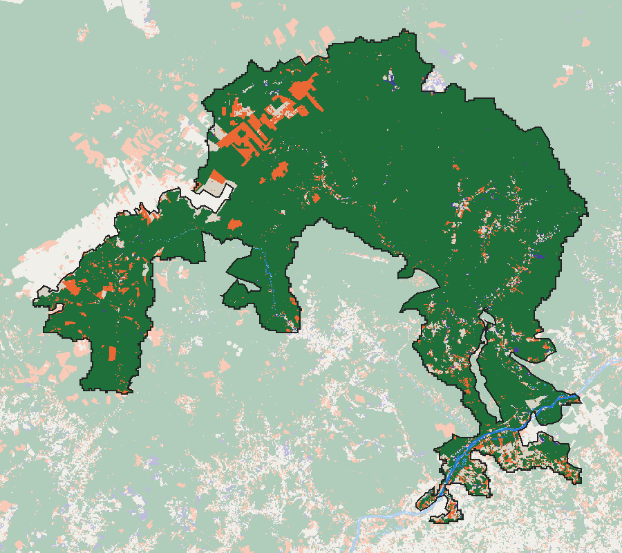

20 km

- Vegetação natural estável574.248 ha · 86,9%
- Perda de vegetação natural42.823 ha · 6,5%
- Ganho de vegetação natural5.050 ha · 0,8%
- Uso antrópico estável34.546 ha · 5,2%
- Água ou areia estável3.089 ha · 0,5%
- Trocas com água ou areia1.170 ha · 0,2%

### Trajetória da área não convertida

Vegetação natural mais água e areia, índice 2012 = 100: é a base da categoria. A linha tracejada é a matriz fora das áreas prioritárias no bioma Cerrado, como **contexto**; não é uma avaliação de efeito.

[figure not shown]

|  | 2012–2025 | 2012–2018 | 2018–2025 | Matriz do bioma 2012–2025 |
| --- | --- | --- | --- | --- |
| Tendência líquida (%/ano da vegetação de 2012) | −0,45 | −0,37 | −0,66 | −0,77 |
| Conversão bruta (%/ano) | 0,62 |  |  | 1,33 |
| Regeneração bruta (%/ano) | 0,15 |  |  | 0,45 |

### Composição da paisagem (ha)

|  | 2012 | 2025 | Variação |
| --- | --- | --- | --- |
| Vegetação natural | 617.476 | 579.794 | −37.683 |
| Formação florestal | 32.334 | 33.319 | +984 |
| Formação savânica | 540.080 | 510.644 | −29.436 |
| Formação campestre | 36.758 | 27.853 | −8.904 |
| Campo alagado | 8.295 | 7.968 | −327 |
| Outras formações naturais | 9 | 9 | +0 |
| Uso antrópico | 39.642 | 77.592 | +37.949 |
| Pastagem | 31.299 | 52.256 | +20.957 |
| Soja | 441 | 4.470 | +4.028 |
| Outras lavouras | 5.855 | 9.300 | +3.445 |
| Mosaico de usos | 1.181 | 10.599 | +9.418 |
| Silvicultura | 592 | 559 | −32 |
| Urbano, mineração e outros | 275 | 408 | +133 |
| Natural não vegetado | 3.807 | 3.541 | −267 |
| Água | 3.807 | 3.541 | −267 |

Vegetação natural: 94,0% da área terrestre em 2012 e 88,2% em 2025.

### Para onde foi a vegetação natural de 2012

Vegetação natural em 2012 que era uso antrópico em 2025 (transição direta).

### De onde veio a regeneração

Uso antrópico em 2012 que era vegetação natural em 2025.

Dinâmica hidrológica (fora da contabilidade): 406 ha de vegetação natural de 2012 eram água ou areia em 2025, e 496 ha fizeram o caminho inverso. Vegetação que virou água e ficou água em 2020–2025 (possível reservatório): 127 ha.

### Persistência

| Vegetação natural de 2012 nunca convertida em uso até 2025 | 571.934 ha | 92,6% |
| --- | --- | --- |
| Vegetação natural de 1985 nunca convertida em uso até 2025 | 555.629 ha | 87,3% |
| Parcela da vegetação natural de 2025 nunca convertida desde 1985 |  | 95,8% |

A diferença entre a vegetação de 2025 e a vegetação nunca convertida é vegetação secundária ou regenerada, que conta como natural no MapBiomas.

### Fogo na vegetação natural estável, 1985–2025

Vegetação que permaneceu natural em todos os anos de 1985 a 2025: savana e campo estáveis somam 519.539 ha e floresta estável 27.107 ha. Savana e campo: **acima do esperado** = fogo repetido com intervalos menores que 3 anos (ao menos dois); **abaixo do esperado** = nenhum fogo nos últimos 20 anos (2006–2025), incluindo o que nunca queimou; **de acordo** = os demais casos, que não são uma afirmação de adequação. Floresta: qualquer fogo é afetação. Os dados são apresentados sem juízo de mérito ou de causa.

Acima do esperado · floresta afetadaDe acordo · floresta não afetadaAbaixo do esperado· barras esmaecidas: matriz

[figure not shown]

Matriz = vegetação estável do Cerrado e do Pantanal fora das áreas prioritárias, como contexto. Áreas úmidas (campo e savana alagáveis): mesma regra, só reportada, sem leitura de categoria, porque o regime depende da inundação.

- **Abaixo do esperado em 74%** da savana e do campo estáveis — robusto: mantém-se acima de 50% com limiar de 25 anos (70%).

#### Mudança entre 2012–2018 e 2019–2025 (savana e campo estáveis)

|  | 2012–2018 | 2019–2025 | Matriz entre 18°S e 12°S 2012–2018 · 2019–2025 |
| --- | --- | --- | --- |
| Área queimada por ano (% da área estável) | 1,7% | 1,6% |  |
| Área com fogo em anos consecutivos (% da área estável) | 0,0% | 0,0% |  |
| **Fogo em julho–agosto** (% do queimado) | **2%** | **1%** | 30% · 21% |
| Fogo na janela crítica, julho–setembro (% do queimado; descritor) | 14% | 18% | 71% · 67% |

2012–20182019–2025

[figure not shown]

Julho e agosto são meses sem raios no Cerrado: o fogo nesses meses é iniciado por pessoas. A janela crítica marca o período de maior estresse hídrico da faixa de latitude e é mostrada só como descritor, porque o sentido da sua mudança depende de onde cai o limite da janela. Método: decisão D15 do projeto.

### Alvos de conservação da área (2ª atualização, listas de 2011–2012)

| Grupo | Alvos |
| --- | --- |
| Plantas | 53 |
| Répteis | 18 |
| Mamíferos | 15 |
| Aves | 10 |
| Anfíbios | 3 |
| Sistemas de terras | 3 |

**Lista de alvos**

- **Anfíbios:** Barycholos ternetzi, Rhinella cerradensis, Rhinella veredas
- **Aves:** Alectrurus tricolor, Alipiopsitta xanthops, Anodorhychus hyacinthinus, Basileuterus leucophrys, Coryphaspiza melanotis, Penelope ochrogaster, Phylloscartes roquettei, Poospiza cinerea, Porphyrospiza caerulescens, Taoniscus nanus
- **Mamíferos:** Carterodon sulcidens, Chrysocyon brachyurus, Clyomys laticeps, Cuniculus paca, Leopardus wiedii, Monodelphis kunsi, Myrmechophaga tridactyla, Ozotoceros bezoarticus, Panthera onca, Priodontes maximus, Puma concolor, Tapirus terrestris, Tayassu pecari, Thalpomys cerradensis, Thyroptera devivoi
- **Plantas:** Andira vermifuga (mart.) benth., Annona coriacea mart., Annona furfuracea a.st.-hil, Axonopus chrysoblepharis (lag.) chase, Bromelia balansae mez, Calliandra carrascana barneby, Callisthene fasciculata mart., Callisthene major mart. & zucc., Cohniella jonesiana (rchb.f.) christenson, Cuphea melvilla lindl., Diospyros burchellii hiern, Encholirium luxor l.b.sm. & r.w.read, Enterolobium ellipticum benth., Eremanthus glomerulatus less., Eugenia dysenterica dc., Eugenia florida dc., Eugenia punicifolia (hbk) dc., Facheiroa cephaliomelana buining & brederoo, Ficus calyptroceras (miq.) miq., Gaya domingensis urb., Guadua paniculata munro, Handroanthus impetiginosus mattos, Handroanthus ochraceus (cham.) mattos, Heteranthera zosterifolia mart., Hymenaea martiana hayne, Jacaranda brasiliana (lam.) pers., Krameria grandiflora a.st.-hil., Lepidaploa aurea (mart. ex dc.) h.rob., Mandevilla hirsuta (a.rich.) k.schum., Mircia lingua (o.berg) mattoso, Myrcia tomentosa (aubl.) dc., Myrcia variabilis dc., Myrciaria cuspidata o.berg, Operculina macrocarpa (l.) urb., Peltogyne confertiflora (mart. ex hayne) benth., Pfaffia glabrata mart., Piptocarpha rotundifolia (less.) baker, Plathymenia foliolosa benth., Pouteria torta (mart.) radlk., Psidium myrsinites dc., Qualea grandiflora mart., Qualea jundiahy warm., Qualea multiflora mart., Qualea parviflora mart., Salvertia convallariodora a.st.-hil., Strychnos bicolor progel, Tabebuia aurea (silva manso) benth. & hook.f. ex *, Terminalia argentea mart., Vernonanthura ferruginea (less.) h.rob., Vernonia desertorum mart., Vochysia gardneri warm., Xylopia aromatica (lam.) mart., Zeyheria digitalis (vell.) hoehne & kuhlm.
- **Répteis:** Anolis meridionalis, Apostolepis flavotorquata, Atractus pantostictus, Bothrops lutzi, Bothrops marmoratus, Chironius flavolineatus, Chironius quadricarinatus, Coleodactylus brachystoma, Epicrates crassus, Hoplocercus spinosus, Kentropyx paulensis, Liophis paucidens, Micrablepharus atticolus, Phalotris nasutus, Stenocercus quinarius, Tropidurus montanus, Tupinambis quadrilineatus, Xenodon nattereri
- **Sistemas de terras:** 1ac4c, 1bc7n, 3ec4n

As listas são históricas e não representam a lista vigente de espécies ameaçadas.